# lab5

Yuchen Song_201830360498 - Xuewen Wang_201830120252

2021/10/9

### Data Loading and Pre-processing

```r
load(url("http://www.openintro.org/stat/data/ames.RData"))
area = ames$Gr.Liv.Area
price = ames$SalePrice
```

### Ex1

B is false.

```r
summary(area)
```

```
##    Min. 1st Qu.  Median    Mean 3rd Qu.    Max.
##     334    1126    1442    1500    1743    5642
```

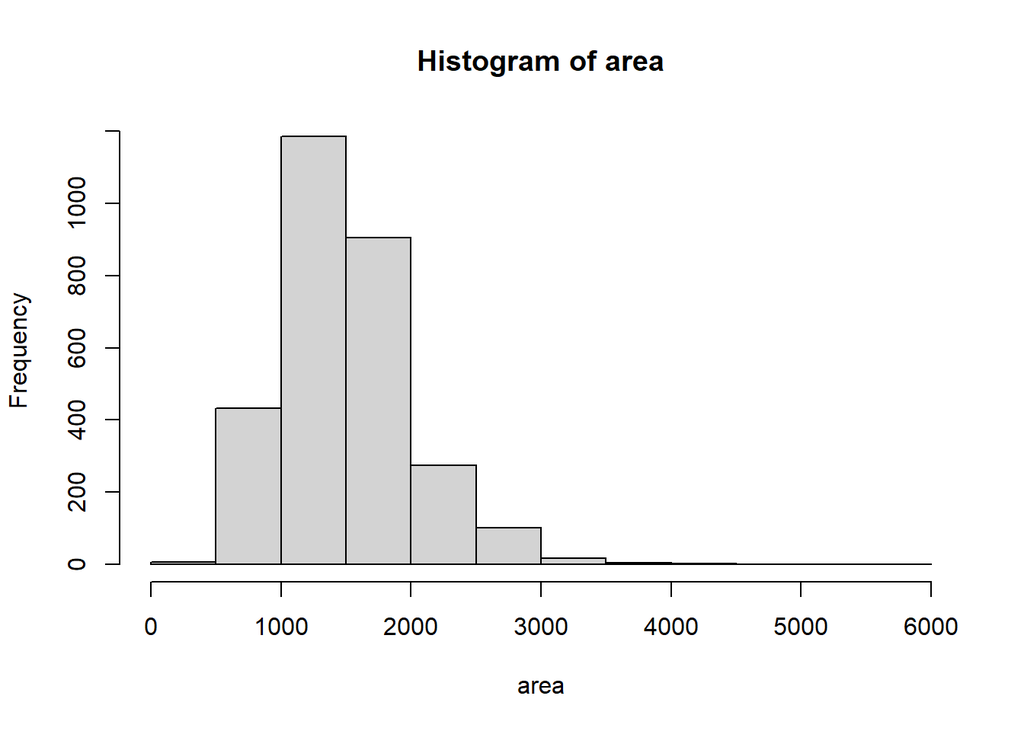

```r
hist(area)
```

A)From the histogram, we can see that it is unimodal and right skewed.  
B)The median of the area is 1442, which implies that more than 50% of the houses in Ames are smaller than 1500 square feet.  
C)It is correct since 1st Qu. is 1126 and 3rd Qu. is 1743.  
D)Yes, the IQR is 617.  
E)Yes, exactly.

### Ex2

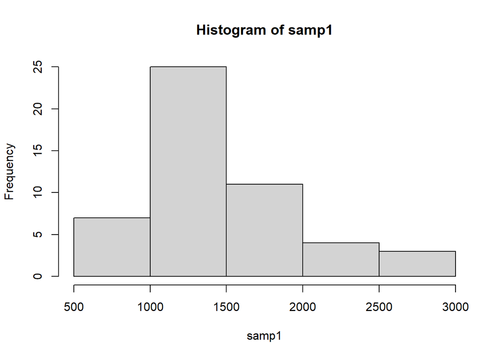

```r
set.seed(1100)
samp1 = sample(area, size = 50, replace = TRUE)
hist(samp1)
```

This sample is unimodal and right-skewed.  
The distribution is similar to that of the population.

### Ex3

```r
mean1 = mean(samp1)
set.seed(1104)
samp2 = sample(area,size = 50,replace = TRUE)
mean2 = mean(samp2)
sprintf("The mean of sample 1 is %f, while the mean of sample2 is %f.",mean1,mean2)
```

```
## [1] "The mean of sample 1 is 1480.200000, while the mean of sample2 is 1484.120000."
```

The mean of sample2 is slightly larger than that of sample1.  
The sample with 1000 cases would achieve a more accurate estimate of the population mean.

### Ex4

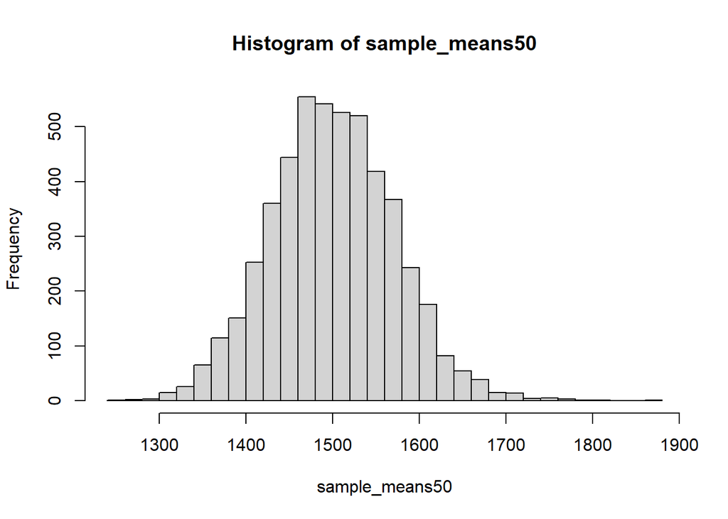

```r
sample_means50 = rep(NA, 5000)
set.seed(1110)
for(i in 1:5000){
  samp = sample(area, size = 50, replace = TRUE)
  sample_means50[i] = mean(samp)
}

hist(sample_means50,breaks = 25)
```

```r
summary(sample_means50)
```

```
##    Min. 1st Qu.  Median    Mean 3rd Qu.    Max.
##    1249    1453    1499    1500    1548    1867
```

There are 5,000 elements in “sample_means50”.  
There are outliers on the right most area.  
The sampling follows a unimodal and nearly Normal distribution, with a center at 1499.  
There is little change if we collected 50,000 samples, but more symmetrical(more close to Normal distribution).

### Ex5

```r
sample_means_small = rep(NA, 100)
set.seed(1120)
for(i in 1:100){
  samp = sample(area, size = 50, replace = TRUE)
  sample_means_small[i] = mean(samp)
}
sample_means_small
```

```
##   [1] 1505.54 1548.28 1526.78 1486.50 1529.56 1552.36 1370.94 1517.36 1463.30
##  [10] 1554.30 1521.10 1562.18 1362.90 1498.92 1532.00 1480.34 1383.08 1477.28
##  [19] 1448.70 1453.44 1554.98 1453.74 1493.98 1516.64 1525.12 1405.96 1436.30
##  [28] 1559.72 1478.96 1480.42 1575.16 1512.64 1519.56 1527.04 1579.52 1428.98
##  [37] 1469.80 1516.38 1348.14 1397.64 1534.50 1635.50 1540.28 1357.62 1463.68
##  [46] 1452.82 1488.48 1366.18 1535.58 1528.08 1393.04 1394.24 1413.66 1567.86
##  [55] 1537.94 1603.10 1411.16 1447.80 1479.68 1466.66 1736.90 1562.40 1444.04
##  [64] 1408.24 1551.78 1418.08 1480.48 1461.92 1448.96 1482.32 1518.16 1454.70
##  [73] 1437.02 1484.92 1553.76 1535.88 1507.58 1441.94 1487.30 1426.40 1441.46
##  [82] 1514.92 1454.18 1614.94 1592.18 1463.12 1451.32 1482.92 1504.90 1647.72
##  [91] 1496.70 1531.04 1494.36 1567.04 1542.14 1429.62 1516.96 1566.48 1509.20
## [100] 1518.12
```

There are 100 elements in the object sample_means_small.  
These elements represents the mean of our randomly chosed sample of 50 from the “area”.

### Ex6

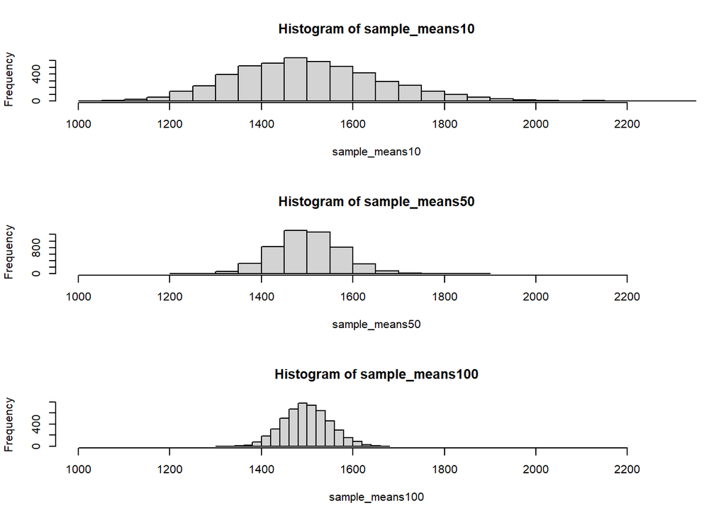

```r
sample_means10 = rep(NA, 5000)
sample_means100 = rep(NA, 5000)
set.seed(1125)
for(i in 1:5000){
  samp = sample(area, size = 10, replace = TRUE)
  sample_means10[i] = mean(samp)
  samp = sample(area, size = 100, replace = TRUE)
  sample_means100[i] = mean(samp)
}

par(mfrow = c(3, 1))

xlimits = range(sample_means10)

hist(sample_means10, breaks = 20, xlim = xlimits)
hist(sample_means50, breaks = 20, xlim = xlimits)
hist(sample_means100, breaks = 20, xlim = xlimits)
```

```r
summary(sample_means10)
```

```
##    Min. 1st Qu.  Median    Mean 3rd Qu.    Max.
##    1003    1389    1492    1503    1606    2300
```

```r
summary(sample_means50)
```

```
##    Min. 1st Qu.  Median    Mean 3rd Qu.    Max.
##    1249    1453    1499    1500    1548    1867
```

```r
summary(sample_means100)
```

```
##    Min. 1st Qu.  Median    Mean 3rd Qu.    Max.
##    1320    1464    1498    1499    1533    1670
```

The center doesn’t change much when the samply size is larger, but it spreads less(more compact and more dense around the center).

### Ex7

```r
set.seed(1130)
samp3 = sample(price, size = 500, replace = TRUE)
```

The best point estimate is the sample mean.

### Ex8

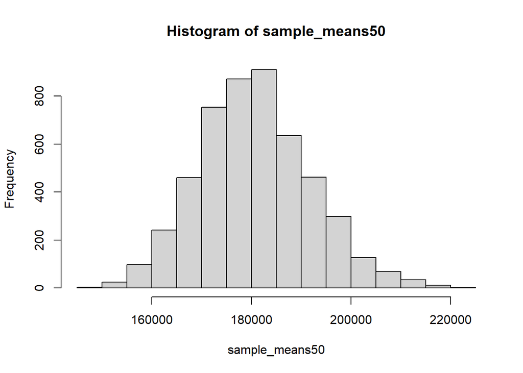

```r
sample_means50 = rep(NA, 5000)
set.seed(1132)

for (i in 1:5000) {
  samp = sample(price, size = 50, replace = TRUE)
  sample_means50[i] = mean(samp)
}

hist(sample_means50)
```

```r
summary(sample_means50)
```

```
##    Min. 1st Qu.  Median    Mean 3rd Qu.    Max.
##  146891  172880  180197  180712  187832  221702
```

```r
mean(price)
```

```
## [1] 180796.1
```

The sampling follows a approximately Normal distribution with center at around 180000.  
We take the mean of sample_means50 as an approximation of the mean of price (180712), which is indeed very close to the mean of the population (180796.1).

### Ex9

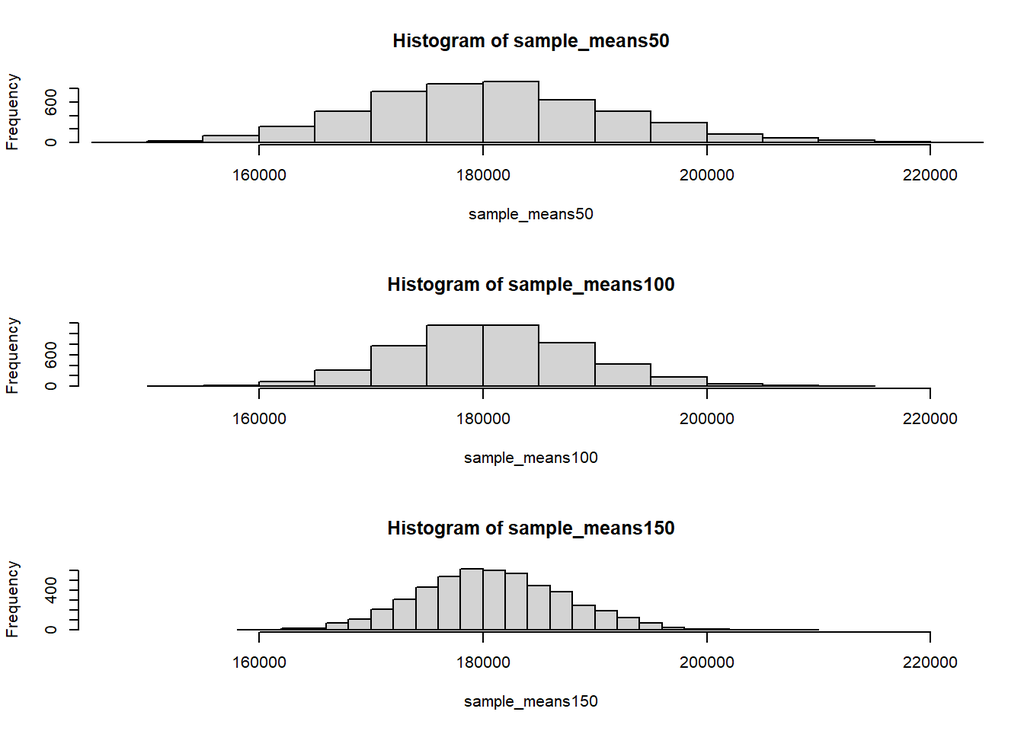

```r
sample_means100 = rep(NA, 5000)
sample_means150 = rep(NA, 5000)
set.seed(1139)
for(i in 1:5000){
  samp = sample(price, size = 100, replace = TRUE)
  sample_means100[i] = mean(samp)
  samp = sample(price, size = 150, replace = TRUE)
  sample_means150[i] = mean(samp)
}

par(mfrow = c(3, 1))

xlimits = range(sample_means50)

hist(sample_means50, breaks = 20, xlim = xlimits)
hist(sample_means100, breaks = 20, xlim = xlimits)
hist(sample_means150, breaks = 20, xlim = xlimits)
```

```r
summary(sample_means50)
```

```
##    Min. 1st Qu.  Median    Mean 3rd Qu.    Max.
##  146891  172880  180197  180712  187832  221702
```

```r
summary(sample_means100)
```

```
##    Min. 1st Qu.  Median    Mean 3rd Qu.    Max.
##  154470  175355  180560  180896  186233  210708
```

```r
summary(sample_means150)
```

```
##    Min. 1st Qu.  Median    Mean 3rd Qu.    Max.
##  159058  176313  180575  180809  185126  209028
```

As the sample size increases, the center of the distribution doesn’t change much, while the spread shrinks and becomes more compact.

### Ex10

The sample size of 150 has a smaller spread.  
We would prefer a small spread when making estimates of the population.